# Reproducing the figures of the manuscript

## Figure 5

**CXCL14 expression in PNP (Figure 5A)**

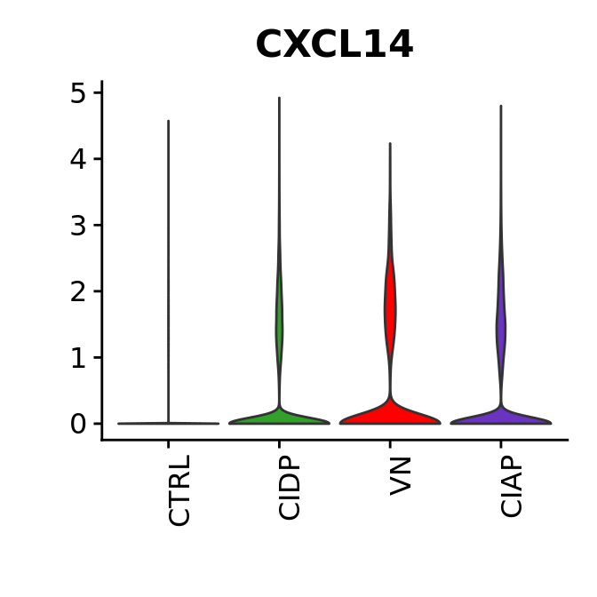

```r
if (!file.exists("perineurial_figure.qs")) {
    download.file(
        "https://zenodo.org/records/15108216/files/perineurial_figure.qs?download=1",
        "perineurial_figure.qs"
    )
}
perineurial_figure <- qread("perineurial_figure.qs")

VlnPlot(
    perineurial_figure,
    features = "CXCL14",
    group.by = "level2",
    cols = perineurial_figure@misc$level2_cols,
    pt.size = 0
) +
    NoLegend() +
    xlab("") +
    ylab("") +
    theme(axis.text.x = element_text(angle = 90, hjust = 1))
```

**Quantification of CXCL14 histololgy in the perineurium (Figure 5B)**

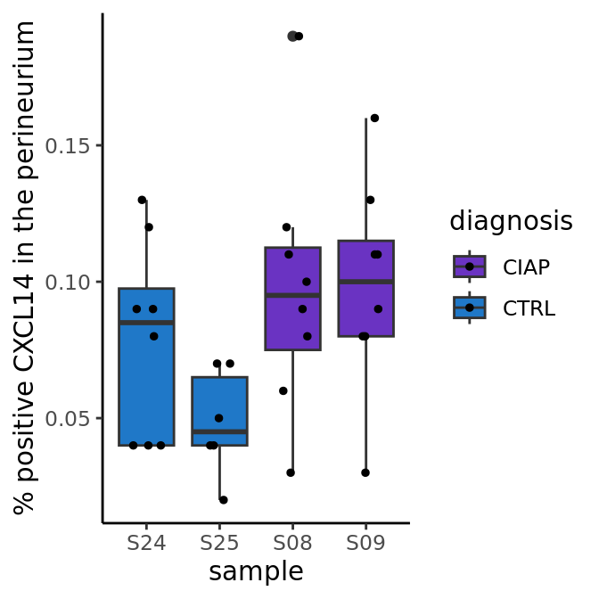

```r
if (!file.exists("cxcl14_data.qs")) {
    download.file(
        "https://zenodo.org/records/15108216/files/cxcl14_data.qs?download=1",
        "cxcl14_data.qs"
    )
}
cxcl14_data <- qread("cxcl14_data.qs")
cxcl14_data$data |>
    ggplot(aes(
        x = sample,
        y = pct_positive,
        fill = diagnosis
    )) +
    geom_boxplot() +
    geom_jitter(width = 0.2, height = 0, size = 1) +
    theme_classic() +
    ylab("% positive CXCL14 in the perineurium") +
    scale_fill_manual(values = cxcl14_data$diagnosis_col)
```

**Perineurium thickness CTRL vs CIDP (Figure 5E)**

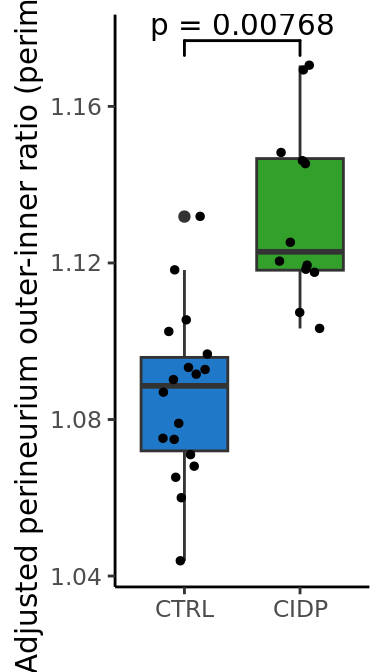

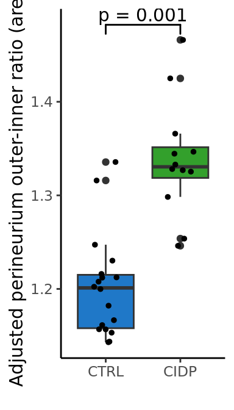

```r
if (!file.exists("data_peri_diagnosis.qs")) {
    download.file(
        "https://zenodo.org/records/15108216/files/data_peri_diagnosis.qs?download=1",
        "data_peri_diagnosis.qs"
    )
}
data_peri_diagnosis <- qread("data_peri_diagnosis.qs")

# function to plot perineurium area/perimeter ratios
plot_peri <- function(data, diagnosis_p_value, y_lab, diagnosis_col) {
    plot <- ggplot(
        data,
        aes(x = diagnosis, y = adjusted_value, fill = diagnosis)
    ) +
        geom_boxplot() +
        geom_jitter(width = 0.2, size = 1) +
        theme_classic() +
        ggsignif::geom_signif(
            comparisons = list(c("CTRL", "CIDP")),
            annotation = paste("p =", signif(diagnosis_p_value, 3))
        ) +
        scale_fill_manual(values = diagnosis_col) +
        theme(legend.position = "none") +
        xlab("") +
        ylab(paste0("Adjusted perineurium outer-inner ratio (", y_lab, ")"))
    return(plot)
}

lapply(
    data_peri_diagnosis,
    function(x) {
        plot_peri(
            data = x$data,
            diagnosis_p_value = x$p_value,
            y_lab = x$y_lab,
            diagnosis_col = x$diagnosis_col
        )
    }
)
```

**Perineurium thickness variances CTRL vs CIDP (Figure 5F)**

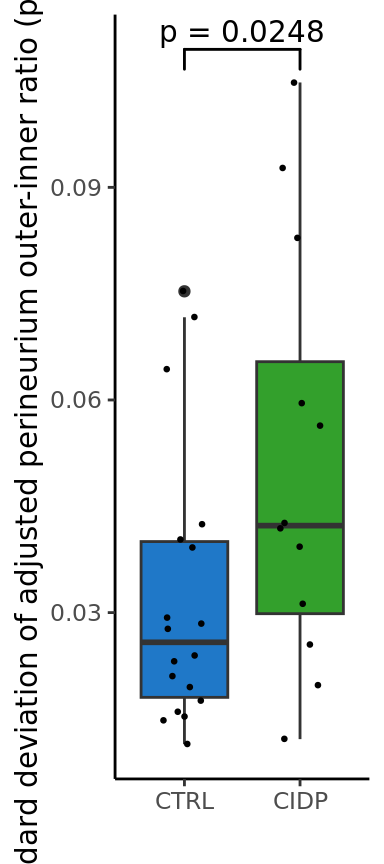

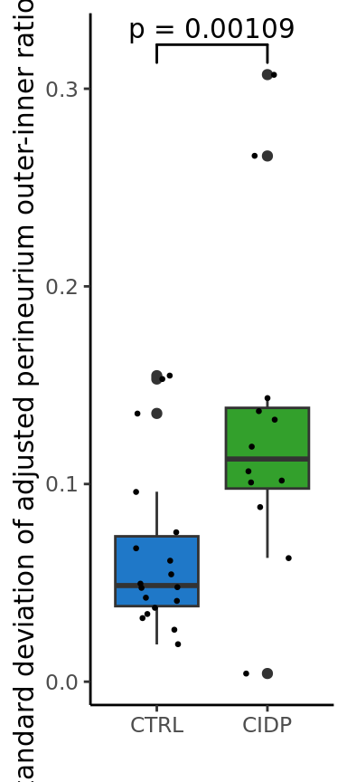

```r
if (!file.exists("data_peri_var.qs")) {
    download.file(
        "https://zenodo.org/records/15108216/files/data_peri_var.qs?download=1",
        "data_peri_var.qs"
    )
}
data_peri_var <- qread("data_peri_var.qs")

# function to plot variance of perineurium area/perimeter ratios
plot_peri_var <- function(data, diagnosis_col, y_lab, var_text) {
    plot <- ggplot(
        data,
        aes(x = diagnosis, y = sd_adjusted, fill = diagnosis)
    ) +
        geom_boxplot() +
        geom_jitter(width = 0.2, size = .5) +
        theme_classic() +
        scale_fill_manual(values = diagnosis_col) +
        theme(legend.position = "none") +
        xlab("") +
        ylab(paste0(
            "Standard deviation of adjusted perineurium outer-inner ratio (",
            y_lab,
            ")"
        )) +
        ggsignif::geom_signif(
            comparisons = list(c("CTRL", "CIDP")),
            annotation = var_text
        )
    return(plot)
}


lapply(
    data_peri_var,
    function(x) {
        plot_peri_var(
            data = x$data,
            var_text = x$var_text,
            y_lab = x$y_lab,
            diagnosis_col = x$diagnosis_col
        )
    }
)
```

## Supplementary Figure 1

**Demographics plot (Figure S1A)**

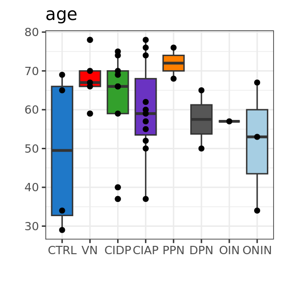

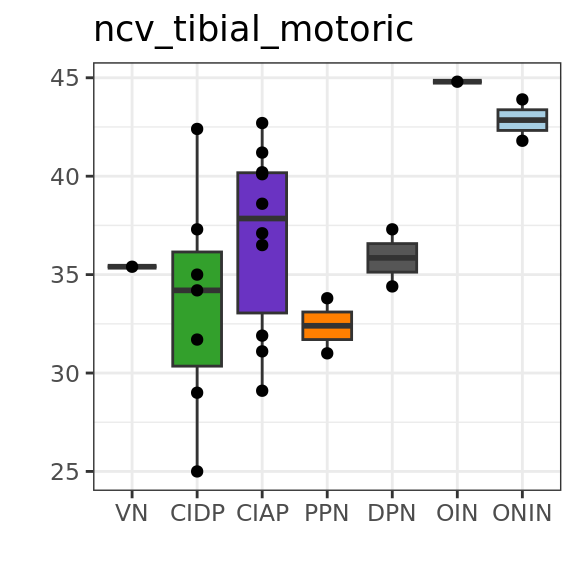

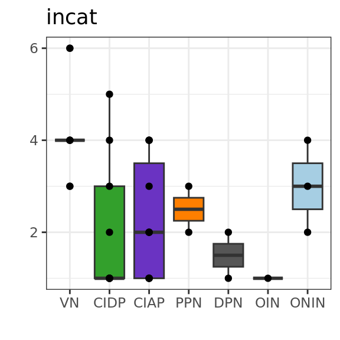

```r
if (!file.exists("demographics.qs")) {
    download.file(
        "https://zenodo.org/records/15108216/files/demographics.qs?download=1",
        "demographics.qs"
    )
}

demographics <- qread("demographics.qs")

plotDemographics <- function(var) {
    plot <- demographics |>
        dplyr::filter(!is.na(.data[[var]])) |>
        ggplot(aes(x = level2, y = .data[[var]], fill = level2)) +
        geom_boxplot() +
        geom_point() +
        theme_bw() +
        scale_fill_manual(values = umap_figure@misc$level2_cols) +
        xlab("") +
        ylab("") +
        ggtitle(var) +
        theme(legend.position = "none")
    print(plot)
}

purrr::walk(c("age", "ncv_tibial_motoric", "incat"), plotDemographics)
```

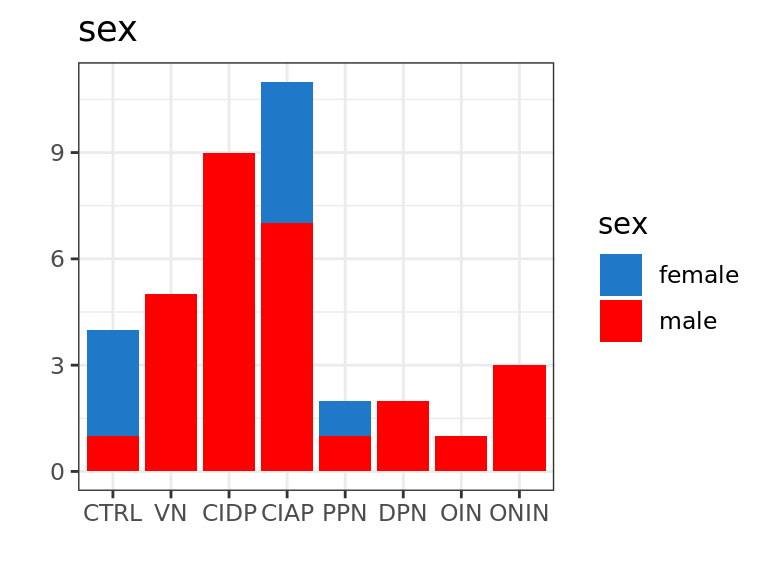

```r
demographics |>
    ggplot(aes(x = level2, fill = sex)) +
    geom_bar() +
    theme_bw() +
    scale_fill_manual(values = pals::cols25(2)) +
    xlab("") +
    ylab("") +
    ggtitle("sex")
```

**UMAP grouped by center and sample (Figure S1C)**

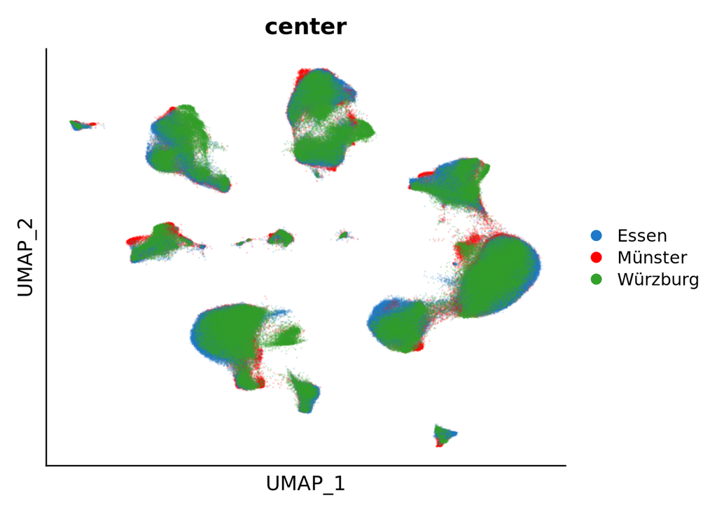

```r
DimPlot(
    umap_figure,
    reduction = "umap.scvi.full",
    pt.size = .1,
    raster = FALSE,
    alpha = 0.1,
    group.by = "center",
    cols = pals::cols25(3),
    label = FALSE
) +
    theme(
        axis.text = element_blank(),
        axis.ticks = element_blank()
    ) +
    xlab("UMAP_1") +
    ylab("UMAP_2")
```

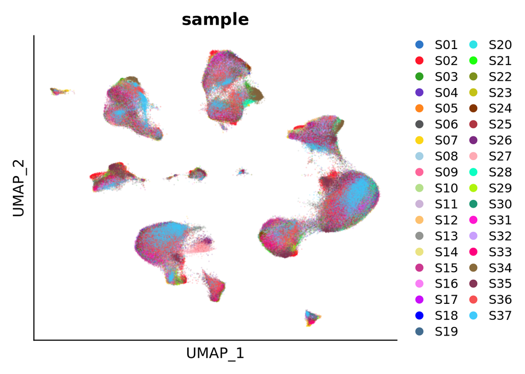

```r
my_cols_50 <- unname(Polychrome::createPalette(50, pals::cols25()))

DimPlot(
    umap_figure,
    reduction = "umap.scvi.full",
    pt.size = .1,
    raster = FALSE,
    alpha = 0.1,
    group.by = "sample",
    cols = umap_figure@misc$sample_cols,
    label = FALSE
) +
    theme(
        axis.text = element_blank(),
        axis.ticks = element_blank()
    ) +
    xlab("UMAP_1") +
    ylab("UMAP_2")
```

**Number of genes per nucleus (Figure S1D)**

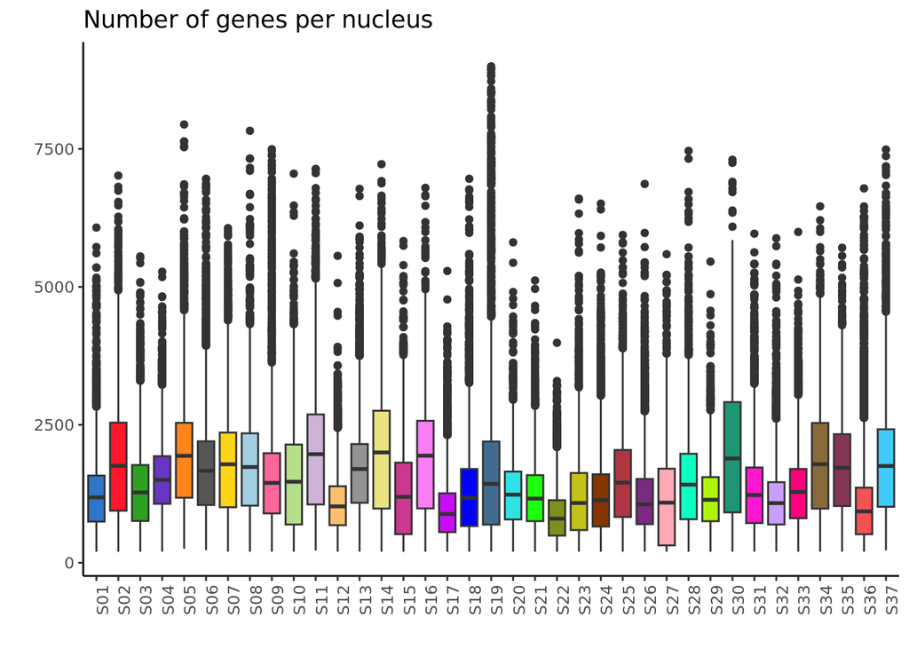

```r
count_genes <- dplyr::tibble(
    feature = umap_figure@meta.data$nFeature_RNA,
    sample = umap_figure@meta.data$sample
)

count_genes |>
    ggplot(aes(x = sample, y = feature, fill = sample)) +
    geom_boxplot() +
    scale_fill_manual(values = umap_figure@misc$sample_cols) +
    theme_classic() +
    theme(legend.position = "none") +
    xlab("") +
    ylab("") +
    ggtitle("Number of genes per nucleus") +
    theme(axis.text.x = element_text(angle = 90))
```

**Abundance of clusters per sample (Figure S1E)**

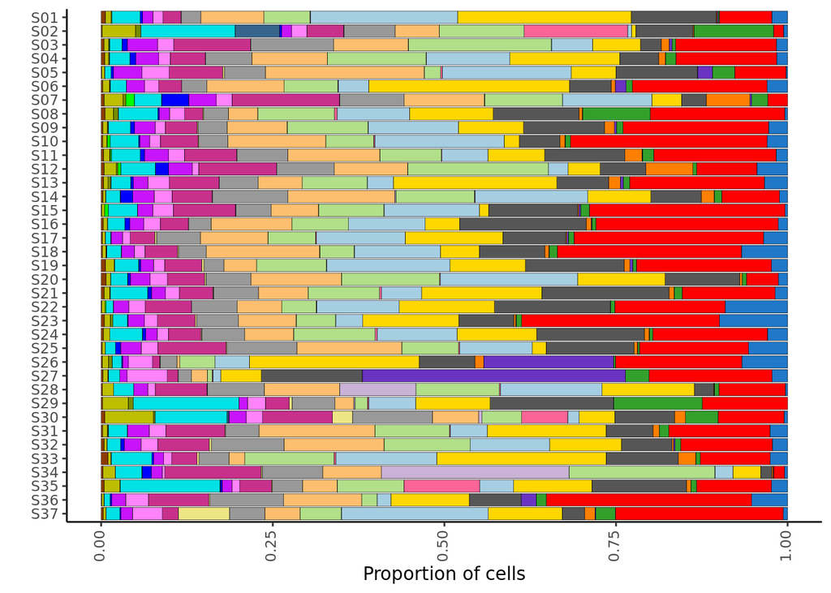

```r
if (!file.exists("abundance_main_clusters_sample.qs")) {
    download.file(
        "https://zenodo.org/records/15108216/files/abundance_main_clusters_sample.qs?download=1",
        "abundance_main_clusters_sample.qs"
    )
}
abundance_main_clusters_sample <- qread("abundance_main_clusters_sample.qs")
abundance_main_clusters_sample |>
    mutate(type = factor(type, levels = rev(levels(factor(type))))) |>
    ggplot() +
    geom_col(
        aes(x = type, y = count, fill = cell),
        color = "black",
        linewidth = 0.1,
        position = "fill"
    ) +
    scale_fill_manual(values = umap_figure@misc$cluster_col) +
    theme_classic() +
    ylab("Proportion of cells") +
    xlab("") +
    theme(
        axis.text.x = element_text(
            angle = 90,
            hjust = 1,
            vjust = 0.3
        ),
        legend.position = "none"
    ) +
    coord_flip()
```

## Supplementary Figure 2

**Dotplot of main clusters(Figure S2A)**

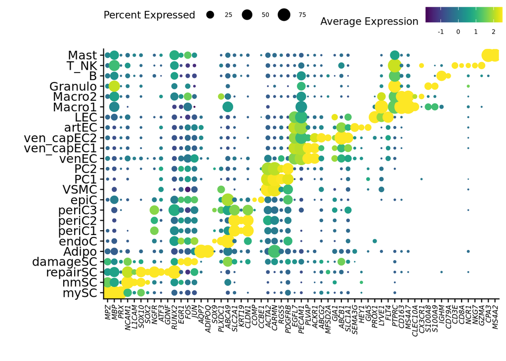

```r
if (!file.exists("dotplot_data.qs")) {
    download.file(
        "https://zenodo.org/records/15108216/files/dotplot_data.qs?download=1",
        "dotplot_data.qs"
    )
}
dotplot_data <- qread("dotplot_data.qs")


DotPlotModified(
    data.plot = dotplot_data,
    scale.by = "size"
) +
    viridis::scale_color_viridis(option = "viridis") +
    theme(
        axis.text.x = element_text(
            angle = 90,
            vjust = 0.5,
            hjust = 1,
            face = "italic",
            size = 7
        ),
        legend.position = "top",
        legend.text = element_text(size = 6),
        legend.title = element_text(size = 10)
    ) +
    xlab("") +
    ylab("")
```

**Enrichment of gene ontology terms of markers genes in periC (Figure S2B)**

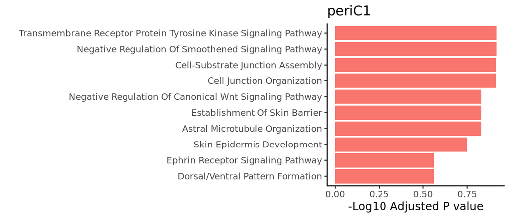

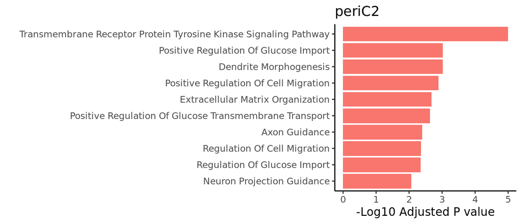

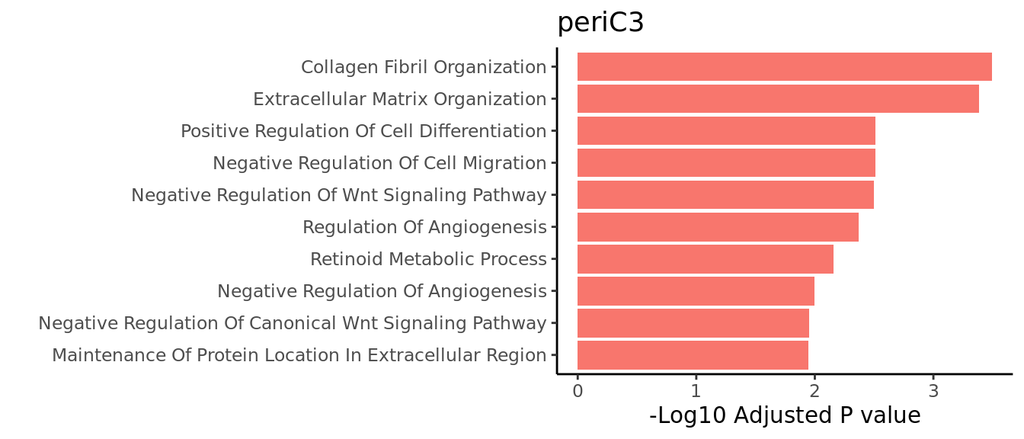

```r
if (!file.exists("enrichr_periC.qs")) {
    download.file(
        "https://zenodo.org/records/15108216/files/enrichr_periC.qs?download=1",
        "enrichr_periC.qs"
    )
}
enrichr_periC <- qread("enrichr_periC.qs")

plotEnrichr <- function(data, name) {
    plot <-
        data |>
        dplyr::slice_min(
            order_by = Adjusted.P.value,
            n = 10,
            with_ties = FALSE
        ) |>
        tidyr::separate(Overlap, into = c("overlap1", "overlap2")) |>
        dplyr::mutate(
            Term = gsub(x = Term, pattern = "\\s\\(.+\\)", replacement = "")
        ) |>
        dplyr::mutate(overlap = as.numeric(overlap1) / as.numeric(overlap2)) |>
        ggplot(aes(
            y = reorder(Term, -log10(Adjusted.P.value)),
            x = -log10(Adjusted.P.value)
        )) +
        geom_col(fill = scales::hue_pal()(5)[1]) +
        labs(
            x = "-Log10 Adjusted P value",
            y = ""
        ) +
        theme_classic() +
        theme(legend.position = "none") +
        ggtitle(name)
    print(plot)
}

purrr::walk2(
    enrichr_periC,
    names(enrichr_periC),
    plotEnrichr
)
```

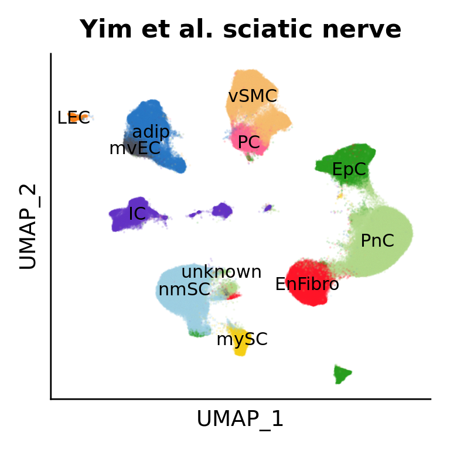

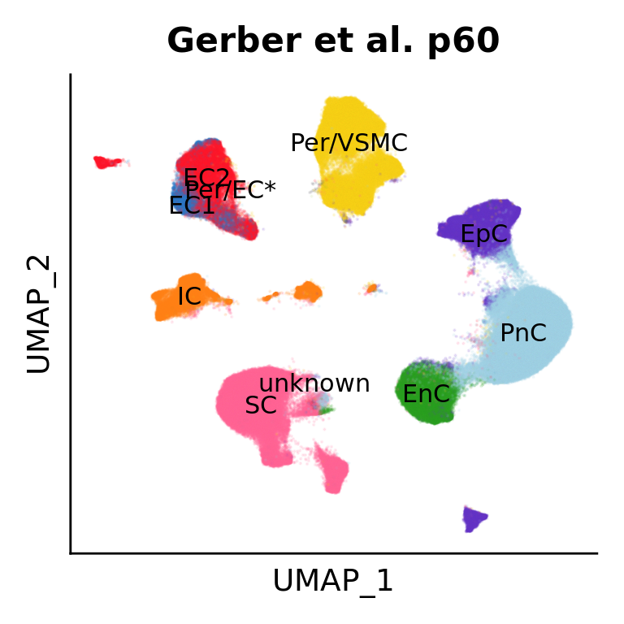

```r
plotUMAP <- function(group, title) {
    plot <-
        DimPlot(
            umap_figure,
            reduction = "umap.scvi.full",
            group.by = group,
            raster = FALSE,
            pt.size = .1,
            alpha = .1,
            cols = umap_figure@misc$sample_cols,
            label = TRUE
        ) +
        theme(
            axis.text = element_blank(),
            axis.ticks = element_blank()
        ) +
        xlab("UMAP_1") +
        ylab("UMAP_2") +
        NoLegend() +
        ggtitle(title)
    print(plot)
}

purrr::walk2(
    c("milbrandt_sciatic_label_full", "suter_p60_label_full"),
    c("Yim et al. sciatic nerve", "Gerber et al. p60"),
    plotUMAP
)
```

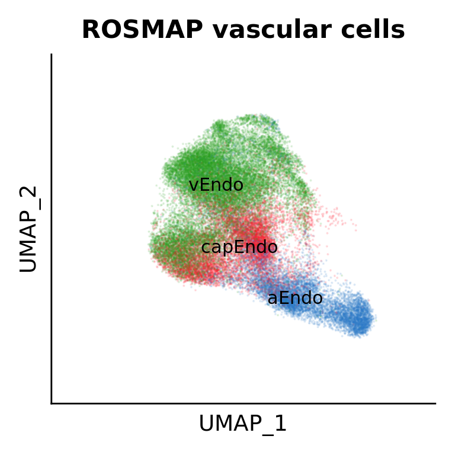

```r
if (!file.exists("ec_rosmap.qs")) {
    download.file(
        "https://zenodo.org/records/15108216/files/ec_rosmap.qs?download=1",
        "ec_rosmap.qs"
    )
}
ec_rosmap <- qread("ec_rosmap.qs")
DimPlot(
    ec_rosmap,
    reduction = "umap.scvi.full",
    group.by = "rosmap_label",
    raster = FALSE,
    pt.size = .1,
    alpha = .1,
    cols = ec_rosmap@misc$sample_cols,
    label = TRUE
) +
    NoLegend() +
    xlim(-12, -5) +
    ylim(2, 10) +
    xlab("UMAP_1") +
    ylab("UMAP_2") +
    ggtitle("ROSMAP vascular cells") +
    theme(
        axis.text = element_blank(),
        axis.ticks = element_blank()
    )
```

**Dotplot of new marker genes in rodent and human datasets (Figure S2D)**

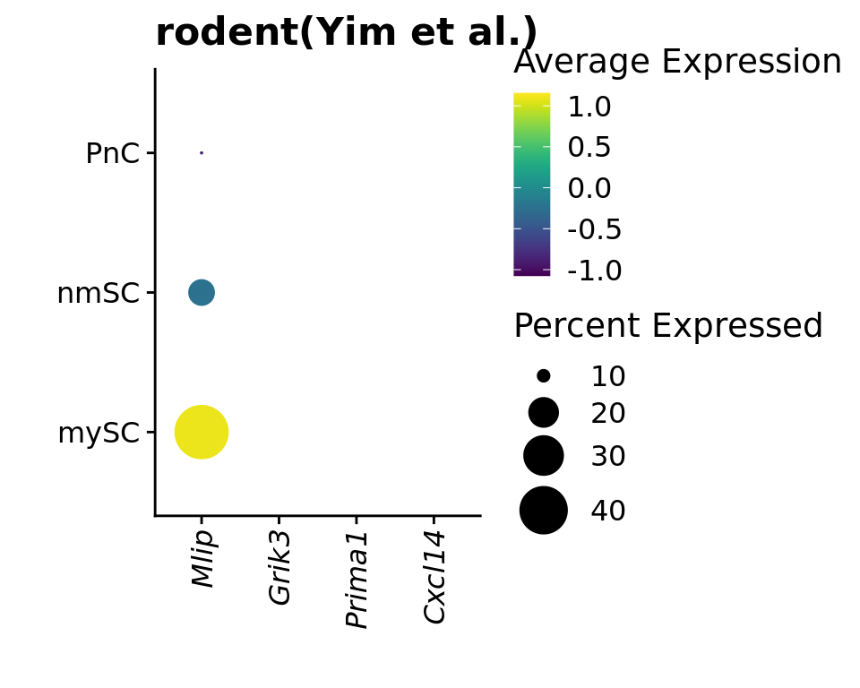

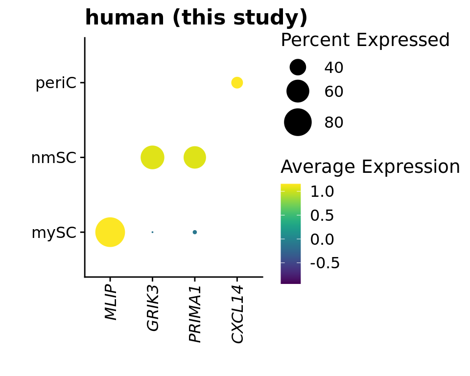

```r
if (!file.exists("dotplot_human_rodent.qs")) {
    download.file(
        "https://zenodo.org/records/15108216/files/dotplot_human_rodent.qs?download=1",
        "dotplot_human_rodent.qs"
    )
}
dotplot_human_rodent <- qread("dotplot_human_rodent.qs")

DotPlotCustom <-
    function(data, title) {
        plot <-
            DotPlotModified(
                data.plot = data,
                scale.by = "size",
                dot.scale = 10,
            ) +
            viridis::scale_color_viridis(option = "viridis") +
            theme(
                axis.text.x = element_text(
                    angle = 90,
                    vjust = 0.5,
                    hjust = 1,
                    face = "italic",
                )
            ) +
            xlab("") +
            ylab("") +
            ggtitle(title)
        print(plot)
    }

purrr::walk2(
    dotplot_human_rodent,
    c("rodent(Yim et al.)", "human (this study)"),
    DotPlotCustom
)
```

## Supplementary Figure 3

**Dotplot CXCR4 expression (Figure S3A)**

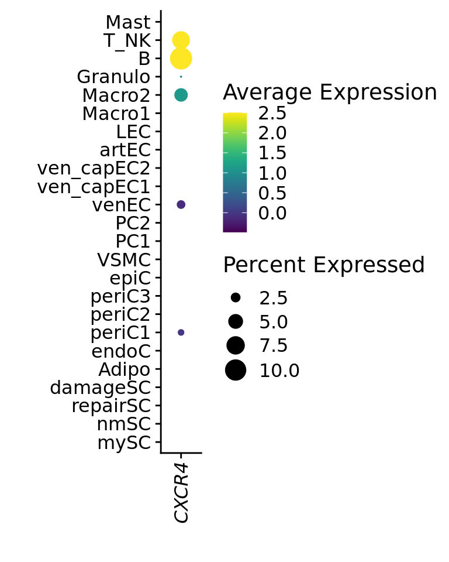

```r
if (!file.exists("dotplot_data_cxcr4.qs")) {
    download.file(
        "https://zenodo.org/records/15108216/files/dotplot_data_cxcr4.qs?download=1",
        "dotplot_data_cxcr4.qs"
    )
}
dotplot_data_cxcr4 <- qread("dotplot_data_cxcr4.qs")

DotPlotModified(
    data.plot = dotplot_data_cxcr4,
    scale.by = "size"
) +
    viridis::scale_color_viridis(option = "viridis") +
    theme(
        axis.text.x = element_text(
            angle = 90,
            vjust = 0.5,
            hjust = 1,
            face = "italic"
        ),
    ) +
    xlab("") +
    ylab("")
```

**Cell-cell interaction analysis (Figure S3B)**

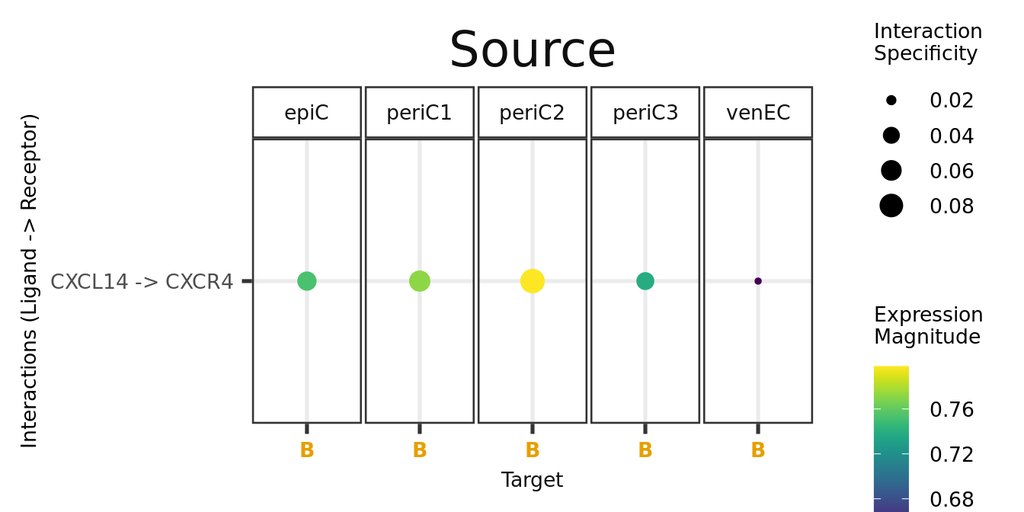

```r
if (!file.exists("liana_results_aggregate.qs")) {
    download.file(
        "https://zenodo.org/records/15108216/files/liana_results_aggregate.qs?download=1",
        "liana_results_aggregate.qs"
    )
}
liana_results_aggregate <- qread("liana_results_aggregate.qs")

liana_results_aggregate |>
    dplyr::filter(ligand.complex == "CXCL14") |>
    liana_dotplot(size_range = c(1, 5)) +
    theme(
        legend.text = element_text(size = 10),
        axis.text.x = element_text(size = 10),
        axis.title.x = element_text(size = 10),
        axis.text.y = element_text(size = 10),
        axis.title.y = element_text(size = 10),
        legend.title = element_text(size = 10),
        strip.text = element_text(size = 10),
    )
```

## Supplementary Figure 4

**Dotplot of immune cell marker genes (Figure S4A)**

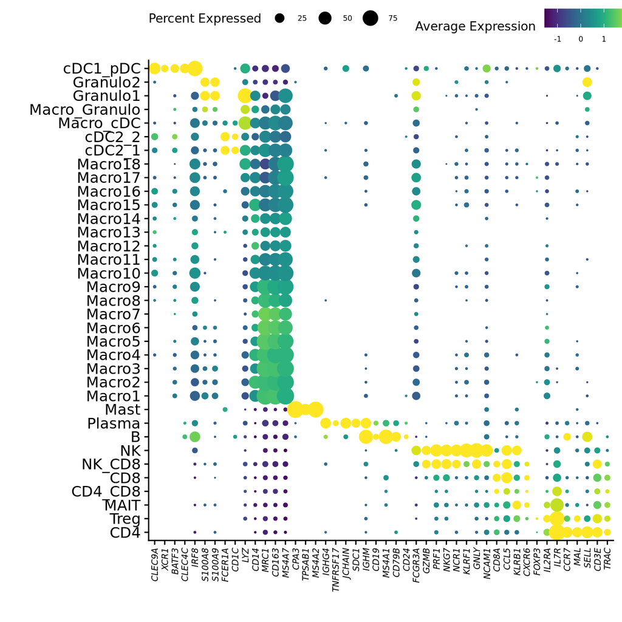

```r
if (!file.exists("dotplot_data_ic.qs")) {
    download.file(
        "https://zenodo.org/records/15108216/files/dotplot_data_ic.qs?download=1",
        "dotplot_data_ic.qs"
    )
}

dotplot_data_ic <- qread("dotplot_data_ic.qs")

DotPlotModified(
    data.plot = dotplot_data_ic,
    scale.by = "size"
) +
    viridis::scale_color_viridis(option = "viridis") +
    theme(
        axis.text.x = element_text(
            angle = 90,
            vjust = 0.5,
            hjust = 1,
            face = "italic",
            size = 7
        ),
        legend.position = "top",
        legend.text = element_text(size = 6),
        legend.title = element_text(size = 10)
    ) +
    xlab("") +
    ylab("")
```

**Dot plot IGH chain genes (Supplementary Figure 4B)**

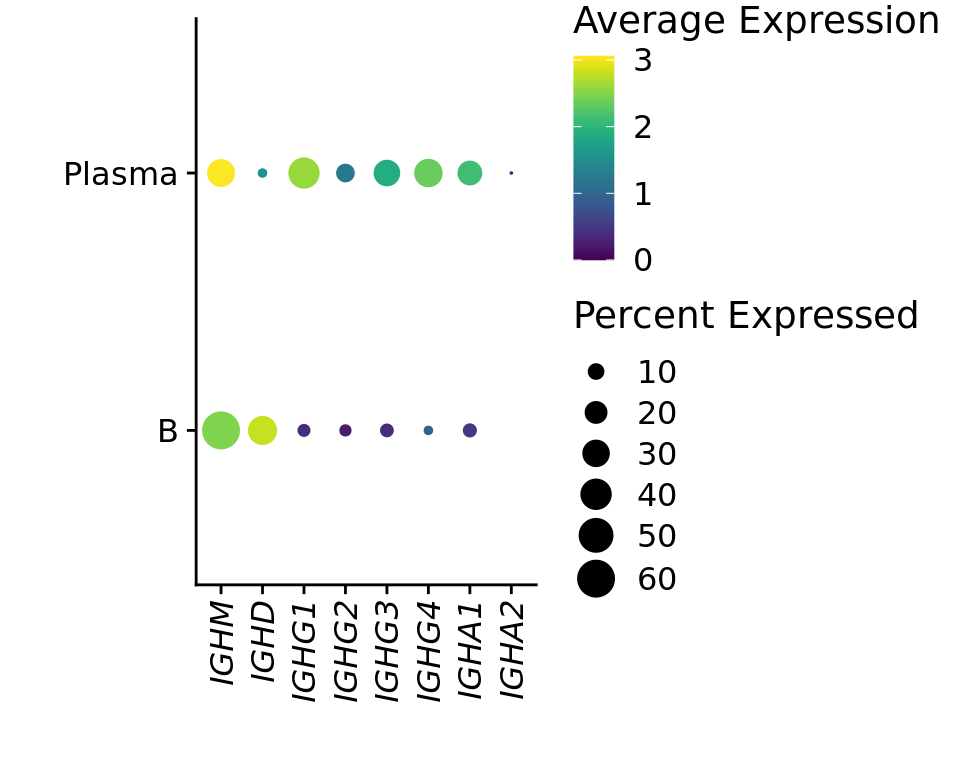

```r
if (!file.exists("dotplot_data_b_plasma.qs")) {
    download.file(
        "https://zenodo.org/records/15108216/files/dotplot_data_b_plasma.qs?download=1",
        "dotplot_data_b_plasma.qs"
    )
}

dotplot_data_b_plasma <- qread("dotplot_data_b_plasma.qs")
DotPlotModified(
    data.plot = dotplot_data_b_plasma,
    scale.by = "size",
) +
    viridis::scale_color_viridis(option = "viridis") +
    theme(
        axis.text.x = element_text(
            angle = 90,
            vjust = 0.5,
            hjust = 1,
            face = "italic"
        ),
    ) +
    xlab("") +
    ylab("")
```

**Enrichment of gene ontology terms in DEG (Figure S4C)**

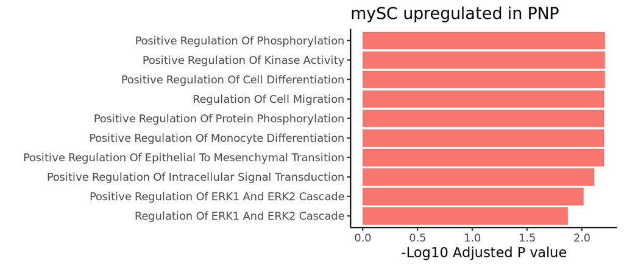

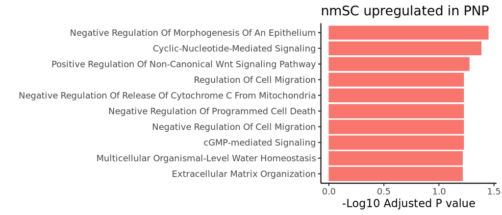

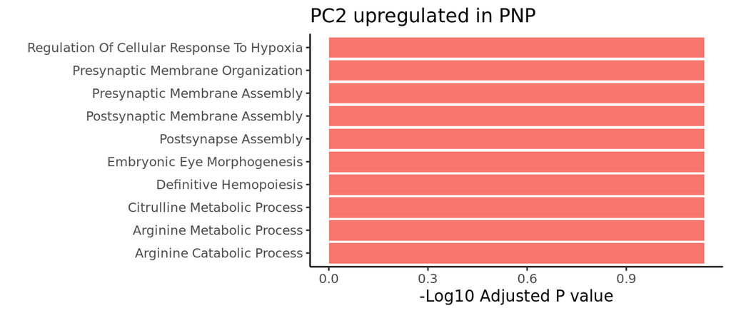

```r
if (!file.exists("enrichr_de.qs")) {
    download.file(
        "https://zenodo.org/records/15108216/files/enrichr_de.qs?download=1",
        "enrichr_de.qs"
    )
}

enrichr_de <- qread("enrichr_de.qs")

purrr::walk2(
    enrichr_de$pos,
    paste0(names(enrichr_de$pos), " upregulated in PNP"),
    plotEnrichr
)
```

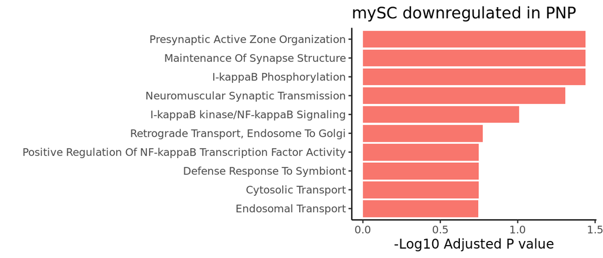

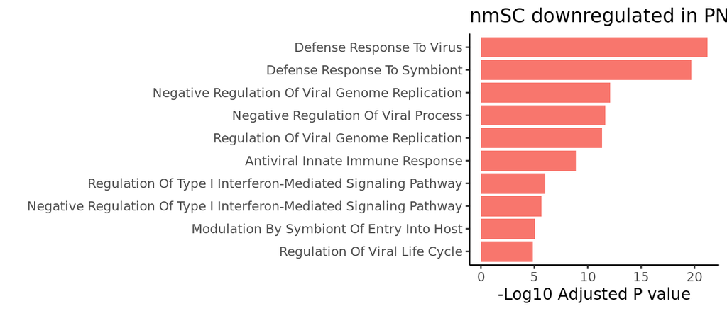

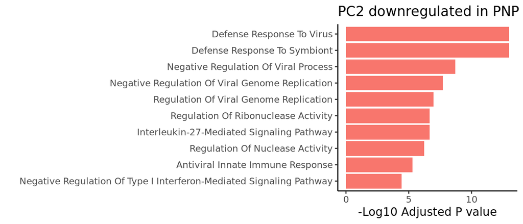

```r
purrr::walk2(
    enrichr_de$neg,
    paste0(names(enrichr_de$neg), " downregulated in PNP"),
    plotEnrichr
)
```

# Supplementary Figure 5

**Boxplots of g-ratio per sample (Figure S5B)**

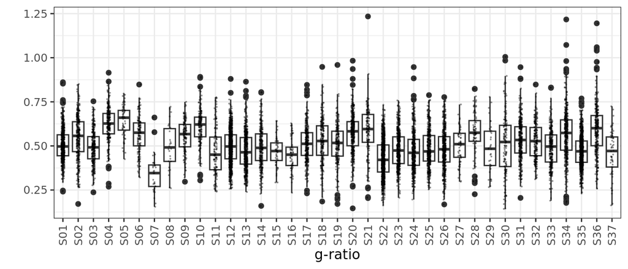

```r
if (!file.exists("g_ratio.qs")) {
    download.file(
        "https://zenodo.org/records/15108216/files/g_ratio.qs?download=1",
        "g_ratio.qs"
    )
}
g_ratio <- qread("g_ratio.qs")

g_ratio |>
    ggplot(aes(x = sample, y = g_ratio)) +
    geom_boxplot() +
    geom_jitter(height = 0, width = 0.1, alpha = 0.3, size = 0.1) +
    theme_bw() +
    theme(axis.text.x = element_text(angle = 90, vjust = 0.5, hjust = 1)) +
    xlab("g-ratio") +
    ylab("")
```

**Boxplots of g-ratio per PNP subtye (Figure S5C)**

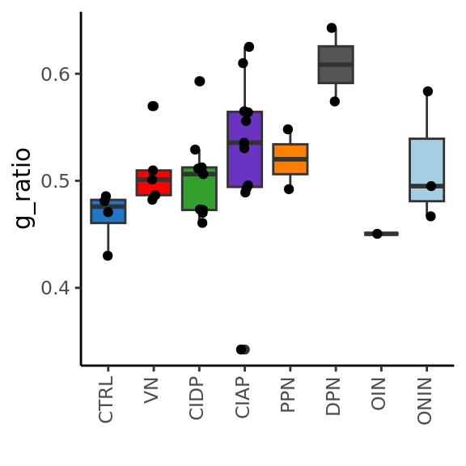

```r
# function to plot boxplots Figure S5C-E
plotBoxplotCustom <-
    function(data, y_var) {
        data |>
            ggplot(aes(x = level2, y = .data[[y_var]], fill = level2)) +
            geom_boxplot() +
            geom_jitter(height = 0, width = 0.1) +
            scale_fill_manual(values = umap_figure@misc$level2_cols) +
            theme_classic() +
            ylab(y_var) +
            xlab("") +
            theme(
                axis.text.x = element_text(
                    angle = 90,
                    hjust = 1,
                    vjust = 0.3
                ),
                legend.position = "none"
            )
    }

g_ratio |>
    group_by(sample) |>
    mutate(g_ratio = mean(g_ratio)) |>
    select(sample, level2, g_ratio) |>
    distinct() |>
    plotBoxplotCustom(y_var = "g_ratio")
```

**Boxplots of axon count per PNP subtype (Figure S5D)**

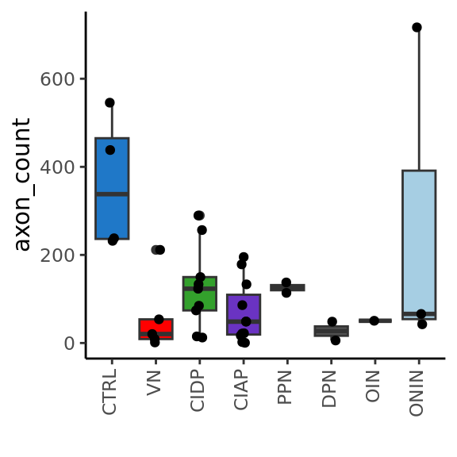

```r
if (!file.exists("axon_count.qs")) {
    download.file(
        "https://zenodo.org/records/15108216/files/axon_count.qs?download=1",
        "axon_count.qs"
    )
}

axon_count <- qread("axon_count.qs")
plotBoxplotCustom(data = axon_count, y_var = "axon_count")
```

**Boxplots of axon diameter per PNP subtype (Figure S5E)**

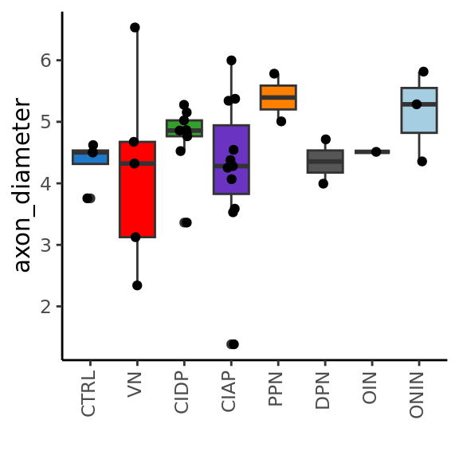

```r
g_ratio_grouped <-
    g_ratio |>
    group_by(sample) |>
    mutate(
        g_ratio = mean(g_ratio),
        ncv_tibial_motoric = mean(ncv_tibial_motoric),
        axon_diameter = mean(axon_diameter)
    ) |>
    ungroup() |>
    select(sample, level2, g_ratio, ncv_tibial_motoric, axon_diameter) |>
    distinct()

plotBoxplotCustom(g_ratio_grouped, y_var = "axon_diameter")
```

**Correlation plots of NCV and histological measures (Figure S5F)**

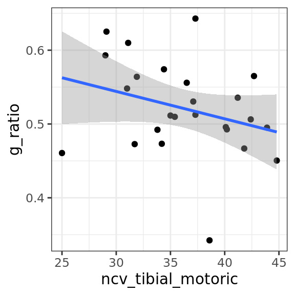

```r
plotCor <- function(data, x, y) {
    ggplot(data, aes(x = .data[[x]], y = .data[[y]])) +
        geom_point() +
        geom_smooth(method = "lm") +
        theme_bw() +
        xlab(x) +
        ylab(y)
}

plotCor(g_ratio_grouped, x = "ncv_tibial_motoric", y = "g_ratio")
```

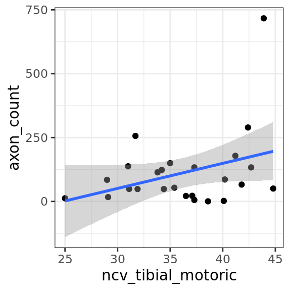

```r
plotCor(axon_count, x = "ncv_tibial_motoric", y = "axon_count")
```

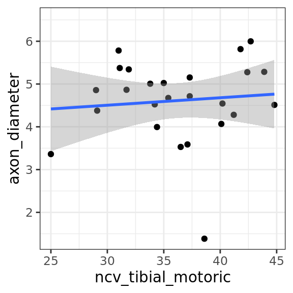

```r
plotCor(g_ratio_grouped, x = "ncv_tibial_motoric", y = "axon_diameter")
```

**Correlation plots of axon count and SC abundance (Figure S5G)**

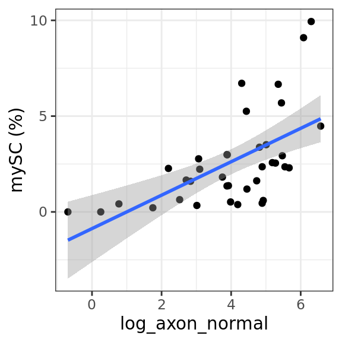

```r
if (!file.exists("abundance_axon.qs")) {
    download.file(
        "https://zenodo.org/records/15108216/files/abundance_axon.qs?download=1",
        "abundance_axon.qs"
    )
}
abundance_axon <- qread("abundance_axon.qs")

abundance_axon |>
    dplyr::filter(cell == "mySC") |>
    plotCor(x = "log_axon_normal", y = "count") +
    ylab("mySC (%)")
```

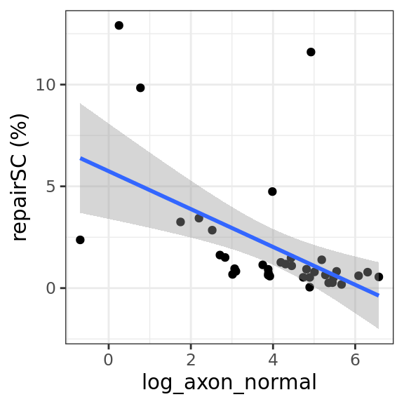

```r
abundance_axon |>
    dplyr::filter(cell == "repairSC") |>
    plotCor(x = "log_axon_normal", y = "count") +
    ylab("repairSC (%)")
```

**Quantification of predicted cluster abundance in Xenium (Figure S5I+M)**

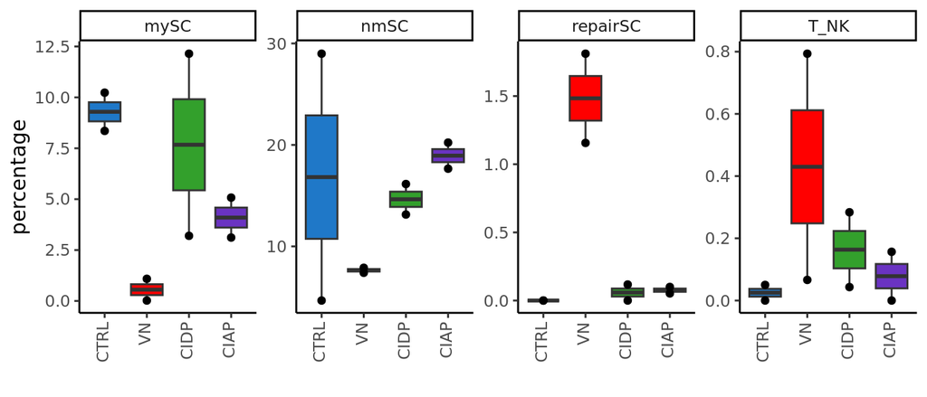

```r
if (!file.exists("xenium_sc_t_nk.qs")) {
    download.file(
        "https://zenodo.org/records/15108216/files/xenium_sc_t_nk.qs?download=1",
        "xenium_sc_t_nk.qs"
    )
}
xenium_sc_t_nk <- qread("xenium_sc_t_nk.qs")
xenium_sc_t_nk |>
    ggplot(aes(x = condition, y = percent, fill = condition)) +
    geom_boxplot() +
    geom_point() +
    theme_classic() +
    facet_wrap(vars(cluster), scales = "free_y", nrow = 1) +
    theme(axis.text.x = element_text(angle = 90, hjust = 1, vjust = 0.3)) +
    xlab("") +
    ylab("percentage") +
    scale_fill_manual(values = umap_figure@misc$level2_cols) +
    theme(legend.position = "none")
```

**Manual CD3E quantification in Xenium (Figure S5J)**

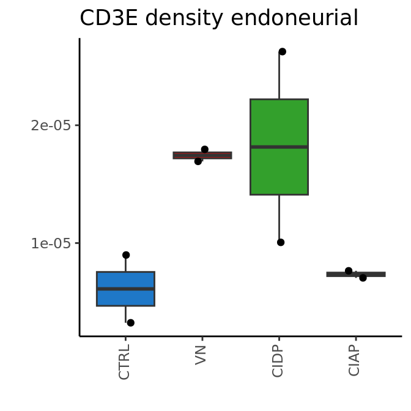

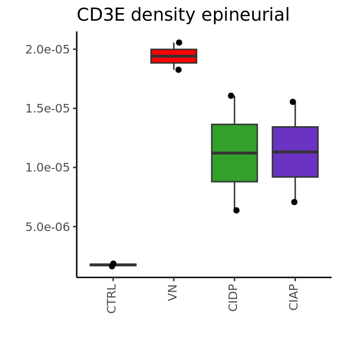

```r
purrr::walk2(
    c("endoCD3E_density_sum", "epiCD3E_density"),
    c("CD3E density endoneurial", "CD3E density epineurial"),
    plotQuanti
)
```

**Manual MS4A1 quantification in Xenium (Figure S5K)**

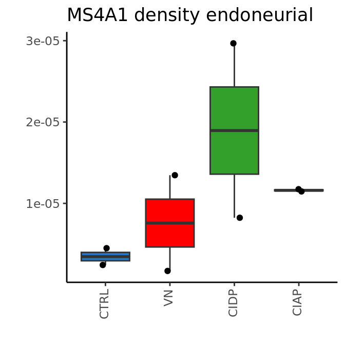

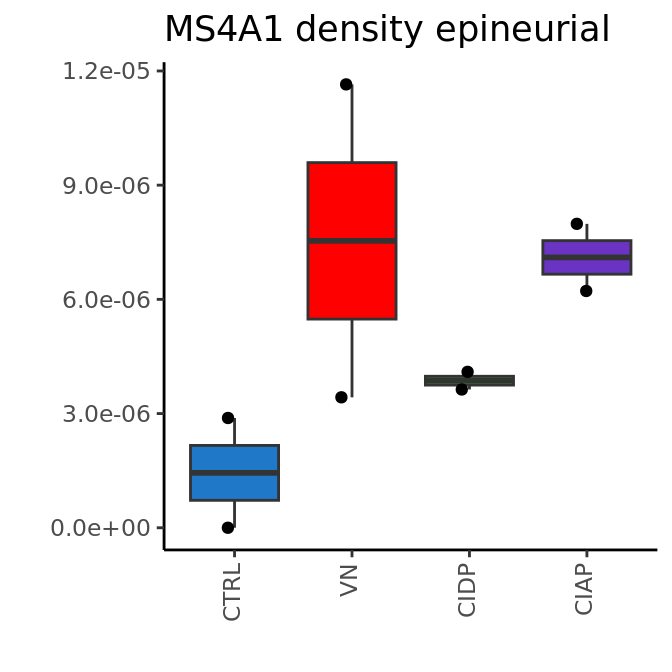

```r
purrr::walk2(
    c("endoMS4A1_density_sum", "epiMS4A1_density"),
    c("MS4A1 density endoneurial", "MS4A1 density epineurial"),
    plotQuanti
)
```

**Manual TREM2 quantification in Xenium (Figure S5N)**

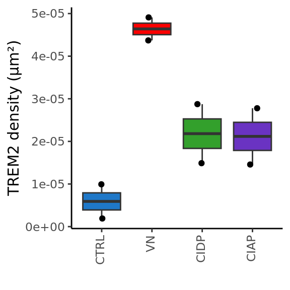

```r
if (!file.exists("xenium_trem2.qs")) {
    download.file(
        "https://zenodo.org/records/15108216/files/xenium_trem2.qs?download=1",
        "xenium_trem2.qs"
    )
}

xenium_trem2 <- qread("xenium_trem2.qs")
xenium_trem2 |>
    ggplot(aes(x = level2, y = density_trem2_mm, fill = level2)) +
    geom_boxplot() +
    geom_jitter(height = 0, width = 0.1) +
    scale_fill_manual(values = umap_figure@misc$level2_cols) +
    theme_classic() +
    ylab("TREM2 density (µm²)") +
    xlab("") +
    theme(
        legend.position = "none",
        axis.text.x = element_text(
            angle = 90,
            hjust = 1,
            vjust = 0.3,
        )
    )
```